# FIT3181: Deep Learning (T1, 2019)

*CE & Lecturer:* Prof **Dinh Phung** | dinh.phung@monash.edu  
*Head Tutor:* Dr **Trung Le** | trunglm@monash.edu  
*Tutor:* Mr **Quan Hoang** | quan.hoang@monash.edu  
Faculty of Information Technology, Monash University, Australia

# Assignment 01: Machine Learning and Deep Neural Networks

### Due: 5:00pm, 5th April 2019 (Friday)

#### Important note: This is an **individual** assignment. It contributes **20%** to your final mark. Read the assignment instruction carefully.

## Instruction

This notebook has been prepared for you to complete Assignment 01. The theme of this assignment is about practical machine learning knowledge and skills in deep neural networks and convolutional neural networks. Some sections have been partially completed to help you get started. **The total marks for this notebook is 100**.

- Before you start, read the entire notebook carefully once to understand what you need to do.
- For each cell marked with **#YOU ARE REQUIRED TO INSERT YOUR CODES IN THIS CELL**, there will be places where you **must** supply your own codes when instructed.

This assignment contains **three** parts:

- **Part 1**: Questions on theory and knowledge on machine learning and deep learning **[20 points]**
- **Part 2**: Coding assessment on TensorFlow for Deep Neural Networks (DNN) **[50 points]**
- **Part 3**: Coding assessment on TensorFlow for Convolution Neural Networks (CNN) **[30 points]**

**Hint**: This assignment was essentially designed based on the lectures and tutorials sessions covered from Week 1 to 5. You are strongly recommended to go through these contents thoroughly which might help you to complete this assignment.

## What to submit

This assignment is to be completed individually and submitted to Moodle unit site. **By the due date, you are required to submit one single zip file, named xxx_assignment01_solution.zip where `xxx` is your student ID, to the corresponding Assignment (Dropbox) in Moodle**.

*For example, if your student ID is 12356, then gather all of your assignment solution to a folder, create a zip file named 123456_assignment01_solution.zip and submit this file.*

Within this zip folder, you **must** submit the following files:

1. **Assignment01_solution.ipynp**: this is your Python notebook solution source file.
2. **Assingment01_output.html**: this is the output of your Python notebook solution *exported* in html format.
3. Any **extra files or folder** needed to complete your assignment (e.g., images used in your answers).

Since this assignment notebook is quite big to load and work together in one go, you might like to split your solution into three parts and work on them seperately. In that case, replace **Assignment01_solution.ipynp** by three notebooks: **Assignment01_Part1_solution.ipynp**, **Assignment01_Part2_solution.ipynp** and **Assignment01_Part3_solution.ipynp**

## Part 1: Theory and Knowledge Questions

[Total marks for this part: 20 points]

The first part of this assignment is for you to demonstrate your knowledge in deep learning that you have acquired from the lectures and tutorials materials. Most of the contents in this assignment are drawn from the tutorials covered from weeks 1 to 5. Going through these materials before attempting this part is highly recommended.

#### **Question 1.1** **Activation function plays an important role in modern Deep NNs. For each of the activation function below, state its output range and find its derivative (show your steps)**

**(a)** Sigmoid: $\sigma(x) = \frac{1}{1+\text{exp}{(-x)}}$

[1.5 points]

**Answer**

Output range: (0, 1)

$\sigma(x) = \frac{1}{1+\text{exp}{(-x)}} = (1+\text{exp}{(-x)})^{-1}$

$\sigma$'(x)

= $-(1+\text{exp}{(-x)})^{-2}(-\text{exp}{(-x)})$

= $(1+\text{exp}{(-x)})^{-2}(\text{exp}{(-x)})$

= $\frac{\text{exp}{(-x)}}{(1+\text{exp}{(-x)})^{2}}$

**(b)** Tanh: $\sigma(x) = \frac{\exp(x) - \exp{(-x)}}{\exp(x) + \exp{(-x)}}$

[1.5 points]

**Answer**

Output range: (-1, 1)

$\sigma$'(x)

= $\frac{(\exp(x) + \exp{(-x)})(\exp(x) - (-1)\exp{(-x)}) - (\exp(x) - \exp{(-x)})(\exp(x) + (-1)\exp{(-x)})}{(\exp(x) + \exp{(-x)})^{2}}$

= $\frac{(\exp(x) + \exp{(-x)})(\exp(x) + \exp{(-x)}) - (\exp(x) - \exp{(-x)})(\exp(x) - \exp{(-x)})}{(\exp(x) + \exp{(-x)})^{2}}$

= $\frac{(\exp(x) + \exp{(-x)})^{2} - (\exp(x) - \exp{(-x)})^{2}}{(\exp(x) + \exp{(-x)})^{2}}$

= $\frac{(\exp(2x) + 2\exp(x)\exp(-x) +\exp{(-2x)}) - (\exp(2x) - 2\exp(x)\exp(-x) + \exp{(-2x)})}{(\exp(x) + \exp{(-x)})^{2}}$

= $\frac{4\exp(x)\exp(-x)}{(\exp(x) + \exp{(-x)})^{2}}$

= $\frac{4}{(\exp(x) + \exp{(-x)})^{2}}$

#### **Question 1.2** **Given the DNN architecture below for classfication task, denote by $n_k$ the number of neurons at layer $k$ for $k=0,1,\ldots,L$, and $M$ be the number of output classes. Answer the the following questions:**

[figure not shown]

**(a)** What are the values for $M$ and $L$?

[1 points]

**Answer**

M = 2

L = 4

**(b)** What are the values of $n_i$ for $i=0,1,\ldots,L$?

[2.5 points]

**Answer**

$n_0$ = 5

$n_1$ = 7

$n_2$ = 5

$n_3$ = 4

$n_4$ = 2

**(c)** Let $k$ the the remainder when you take your student id number and divide it by $4$. For example, if your student id number is $12001$ then $k = 1$, if it is $12004$ then $k = 0$. What is the dimension for $W^{k+1}$ and $b^{k+1}$?

[2 points]

**Answer**

remainder = 28279174 mod 4 = 2

dimension of $W^{3}$ = (5,4) or 5x4

dimension of $b^{3}$ = (1,4) or 1x4

**(d)** Excluding $M$ and $L$, what is the total number of learnable parameters for this network?

[1.5 points]

**Answer**

Type of learnable parameters: W (Weight) and b (bias)

The number of W parameters: $ 5 \times 7 + 7 \times 5 + 5 \times 4 + 4 \times 2 = 35 + 35 + 20 + 8 = 98$

The number of b parameters: $ 7 + 5 + 4 + 2 = 18$

$\therefore$ The total number of learnable parameters: $98 + 18 = 116$

**(e)** Assume the last layer has the value of $h^L(x) = [0.35, 0.12]$, what would be the output value $y$ and why?

[1 point]

**Answer**

y = [0.56, 0.44]

because it would be going through the softmax function for normalization after getting the value of the last layer. The softmax function is shown as follows:

$$softmax(z)=\big[\frac{\exp(z_i)}{\sum_{j=1}^{C}{\exp(z_j)}}\big]_{i=1}^{C}$$

where

- z is the input that contains the value of last layer
- i is the current value
- j is the starting index summation starts performing
- C is the number of classes

The softmax function is needed as it would make the comparison towards the result easier.

#### **Question 1.3** **Given the DNN architecture below for regression task. This DNN has three layers, assuming all bias terms are zero. The input layer has dimension $M$, the output layer has dimension $K$, the hidden layer has two nodes and uses *sigmoid* activation function**. Assume the weight goes from $x_m$ to $h_i$ is $w^h_{im}$, and the weight goes from $h_i$ to $y_k$ is $w^o_{ki}$. Given a single training input $(x,y)$ where $y=(y_1, \ldots,y_K)$ is a vector of $K$ dimension. Answer the following questions in regarding to back propagation procedure for this network:

[figure not shown]

**(a)** What are the expressions to compute forward propagation for $h_1$, $h_2$ and $\hat{y}_k$?

[1.0 point]

**Answer**

- $h_1 = sigmoid(\sum_{m=1}^{M}{(w^h_{1m} \times x_m)})$
- $h_2 = sigmoid(\sum_{m=1}^{M}{(w^h_{2m} \times x_m)})$
- $\hat{y}_k = w^o_{ki} \times h_i$

**(b)** What are the gradient descent (GD) update equation for $w^o_{11}$ and $w^o_{k1}$ in general for $k=1,\ldots,K$ (show your derivation)?

[2.5 points]

Answer

Input: ($x$, $y$)

$\hat{y} = forward(x)$

$\hat{y}_k = w^o_{k1}h_1 + w^o_{k2}h_2$

Goal: minimize $J_t(w) = \frac{1}{2} \sum_{k=1}^{K}{(\hat{y}_k - y_k)^{2}}$

#### For $w^o_{11}:$

We know that...

**(1)** $\hat{y}_1 = w^o_{11}h_1 + w^o_{12}h_2$

**(2)** $\begin{equation*} \frac{\partial \hat{y}_1}{\partial w^o_{11}} \\ = h_1 \end{equation*}$

**(3)** $\begin{equation*} \frac{\partial J_t(w)}{\partial \hat{y}_1} \\ =\frac{\partial J_t(w)_1}{\partial \hat{y}_1} + \frac{\partial J_t(w)_2}{\partial \hat{y}_1} + \ldots + \frac{\partial J_t(w)_K}{\partial \hat{y}_1}\\ = \frac{\partial \left(\frac{1}{2} (\hat{y}_1 - y_1)^{2} \right)}{\partial \hat{y}_1} + 0 + \ldots + 0 \\ = (\hat{y}_1 - y_1) \end{equation*}$

By using the fact above, we can conclude that...

\begin{align*} \frac{\partial J_t(w)}{\partial w^o_{11}} &= \frac{\partial J_t(w)}{\partial \hat{y}_1} \times \frac{\partial \hat{y}_1}{\partial w^o_{11}} \\ &= (\hat{y}_1 - y_1)h_1 \end{align*}

$\therefore$ `GD update for` $w^o_{11} \leftarrow w^o_{11} - \eta(\hat{y}_1 - y_1)h_1$

#### For $w^o_{k1}:$

We know that...

`GD update for` $w^o_{11} \leftarrow w^o_{11} - \eta(\hat{y}_1 - y_1)h_1$

`GD update for` $w^o_{21} \leftarrow w^o_{21} - \eta(\hat{y}_2 - y_2)h_1$

$\vdots$   (Same goes to $w^o_{31}, w^o_{41}, \ldots , w^o_{K1}$)

Therefore, for $w^o_{k1}:$

$\therefore$ `GD update for` $w^o_{k1} \leftarrow w^o_{k1} - \eta(\hat{y}_k - y_k)h_1$ </font>

**(c)** What are the gradient descent (GD) update equation for $w^h_{11}$ and $w^h_{1m}$ in general for $m=1, \ldots, M$ (show your derivation)?

[2.5 points]

Answer

Input: ($x$, $y$)

$\hat{y} = forward(x)$

$\hat{y}_k = w^o_{k1}h_1 + w^o_{k2}h_2$

$h_1 = \sigma(\bar{h_1})$ where $\bar{h_1} = \sum_{m=1}^{M}{(w^h_{1m} \times x_m)}$

Goal: minimize $J_t(w) = \frac{1}{2} \sum_{k=1}^{K}{(\hat{y}_k - y_k)^{2}}$

#### For $w^h_{11}:$

We know that...

**(1)** $\begin{equation*} \frac{\partial \bar{h_1}}{\partial w^h_{11}} \\ = \frac{\partial \left(w^h_{11} \:\times\: x_1 \:+\: w^h_{12} \:\times\: x_2 \:+\: \ldots \:+\: w^h_{1M} \:\times\: x_M \right)}{\partial w^h_{11}} \\ = x_1 \end{equation*}$

**(2)** $\begin{equation*} \frac{\partial h_1}{\partial \bar{h_1}} \\ = \frac{\partial \sigma(\bar{h_1})}{\partial \bar{h_1}} \\ = \sigma(\bar{h_1})(1-\sigma(\bar{h_1})) \\ = h_1(1-h_1) \end{equation*}$

**(3)** $\begin{equation*} \frac{\partial \hat{y}_k}{\partial h_1} \\ = w^o_{k1} \end{equation*}$

**(4)** $\begin{equation*} \frac{\partial J_t(w)}{\partial \hat{y}_k} \\ = (\hat{y}_k - y_k) \end{equation*}$ (derived from 1.3b equation (3))

**(5)** $\begin{equation*} \frac{\partial J_t(w)_k}{\partial h_1} \\ = \frac{\partial J_t(w)_k}{\partial \hat{y}_k} \times \frac{\partial \hat{y}_k}{\partial h_1} \\ = (\hat{y}_k - y_k)(w^o_{k1}) \end{equation*}$

**(6)** $\begin{equation*} \frac{\partial J_t(w)}{\partial h_1} \\ = \frac{\partial J_t(w)_1}{\partial h_1} + \frac{\partial J_t(w)_2}{\partial h_1} + \ldots + \frac{\partial J_t(w)_K}{\partial h_1} \\ = (\hat{y}_1 - y_1)(w^o_{11}) + (\hat{y}_2 - y_2)(w^o_{21}) + \ldots + (\hat{y}_K - y_K)(w^o_{K1}) \\ = \begin{bmatrix} \hat{y}_1 - y_1 \\ \hat{y}_2 - y_2 \\ \vdots \\ \hat{y}_K - y_K \\ \end{bmatrix} \cdot \begin{bmatrix} w^o_{11} \\ w^o_{21} \\ \vdots \\ w^o_{K1} \end{bmatrix} \\ = \left(\begin{bmatrix} \hat{y}_1 \\ \hat{y}_2 \\ \vdots \\ \hat{y}_K \\ \end{bmatrix} - \begin{bmatrix} y_1 \\ y_2 \\ \vdots \\ y_K \\ \end{bmatrix} \right) \cdot \begin{bmatrix} w^o_{11} \\ w^o_{21} \\ \vdots \\ w^o_{K1} \end{bmatrix} \\ = (\hat{y} - y)\cdot(w^o_{1}) \end{equation*}$ ($w^o_{1}$ = a vector that contains all the weights from $h_1$)

By using the fact above, we can conclude that...

\begin{align*} \frac{\partial J_t(w)}{\partial w^h_{11}} &= \frac{\partial J_t(w)}{\partial \bar{h_1}} \times \frac{\partial \bar{h_1}}{\partial w^h_{11}} \\ &= \frac{\partial J_t(w)}{\partial h_1} \times \frac{\partial h_1}{\partial \bar{h_1}} \times \frac{\partial \bar{h_1}}{\partial w^h_{11}} \\ &= [(\hat{y} - y)\cdot(w^o_{1})](h_1)(1-h_1)(x_1) \end{align*}

$\therefore$ `GD update for` $w^h_{11} \leftarrow w^h_{11} - \eta[(\hat{y} - y)\cdot(w^o_{1})](h_1)(1-h_1)(x_1)$

#### For $w^h_{1m}:$

We know that...

`GD update for` $w^h_{11} \leftarrow w^h_{11} - \eta[(\hat{y} - y)\cdot(w^o_{1})](h_1)(1-h_1)(x_1)$

`GD update for` $w^h_{12} \leftarrow w^h_{12} - \eta[(\hat{y} - y)\cdot(w^o_{1})](h_1)(1-h_1)(x_2)$

$\vdots$   (Same goes to $w^h_{13}, w^h_{14}, \ldots , w^h_{1M}$)

Therefore, for $w^h_{1m}:$

$\therefore$ `GD update for` $w^h_{1m} \leftarrow w^h_{1m} - \eta[(\hat{y} - y)\cdot(w^o_{1})](h_1)(1-h_1)(x_m)$ </font>

**(d)** What are the gradient descent (GD) update equation for $w^h_{im}$ in general for $i=1,2$ and $m=1, \ldots, M$ (show your derivation)?

[3 points]

Answer

According to 1.3c:

Since we have the GD update for $w^h_{1m}$, the same derivation process goes to $w^h_{2m}$ (simply replace "1" with "2")

## Part 2: Deep Neural Networks (DNN)

[Total marks for this part: 50 points]

The second part of this assignment is for you to demonstrate your basis knowledge in deep learning that you have acquired from the lectures and tutorials materials. Most of the contents in this assignment are drawn from the tutorials covered from weeks 1 to 5. Going through these materials before attempting this assignment is highly recommended.

*Run the following cell to create necessary subfolders for this assignment. You must **not** modify these codes and **must** run it first*.

```python
# Create necessary subfolders to store immediate files for this assignment.

import os
if not os.path.exists("./models/dnn0"):
    os.makedirs("models/dnn0")
```

For this part, you are going to work with the **notMNIST** dataset for *letter recognition task*. The dataset contains 10 classes of letters A-J taken from different fonts. A short blog about the data can be found [here](http://yaroslavvb.blogspot.com.au/2011/09/notmnist-dataset.html).

Here we only consider a small subset which can be found at [this link](http://yaroslavvb.com/upload/notMNIST/notMNIST_small.mat). This file has been already downloaded and stored in subfolder `datasets` of this assignment folder. The file is in *Matlab* format, thus your first task is to:

#### **Question 2.1**. Load the data into *`numpy array`* format of two variables:

- *`x`*: storing features with dimension `[num_samples, width, height]` (`num_samples`: number of samples, `width`: image width, `height`: image height), and
- *`y`*: storing labels with dimension `num_samples`.

  [2 points]

Enter the missing codes in the following cell to complete this question.

```python
# YOU ARE REQUIRED TO INSERT YOUR CODES IN THIS CELL

import numpy as np
import scipy.io as sio
data = sio.matlab.loadmat("datasets/notMNIST_small.mat")
x, y = data['images'], data['labels'] # INSERT YOUR CODE HERE
x = np.rollaxis(x, axis=2)
```

#### **Question 2.2**. Print out the total number of data points, and the *unique* labels in this dataset.

[2 points]

```python
# YOU ARE REQUIRED TO INSERT YOUR CODES IN THIS CELL
print("Total number of data points: {}".format(x.size))
print("Total number of unique labels: {}".format(len(np.unique(y))))
```

```
Total number of data points: 14679616
Total number of unique labels: 10
```

#### **Question 2.3**. Display 100 images in the form of `10x10` matrix, each row showing 10 *random* images of a label. You might decide to use the function `display_images` provided at the beginning of this assignment, or you can write your own codes.

[2 points]

```python
# this function is provided for you as a utility to display images from the dataset
import numpy as np
import matplotlib.pyplot as plt
%matplotlib inline

def display_images(images, shape):
    fig = plt.figure(figsize=shape)
    fig.subplots_adjust(left=0, right=1, bottom=0, top=1, hspace=0.05, wspace=0.05)
    for i in range(np.prod(shape)):
        p = fig.add_subplot(shape[0], shape[1], i+1, xticks=[], yticks=[])
        p.imshow(images[i], cmap=plt.cm.bone)
```

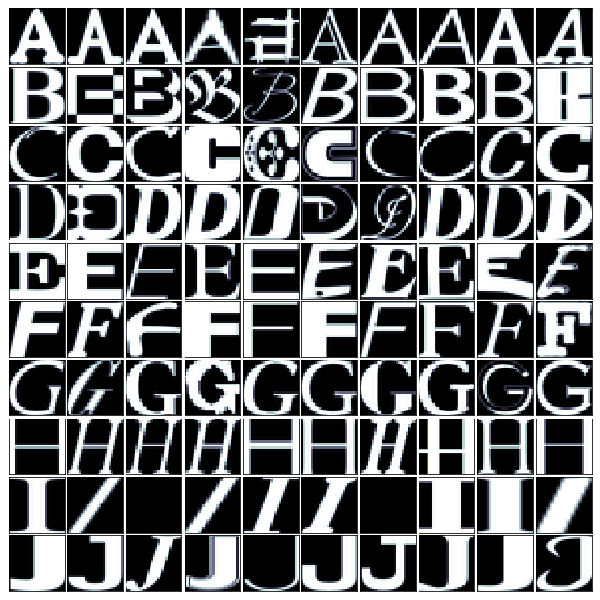

```python
# YOU ARE REQUIRED TO INSERT YOUR CODES IN THIS CELL

unique_labels = np.unique(y) # INSERT YOUR CODE HERE
images = []
for l in unique_labels:
    idx = np.where(y == l)[0]
    idx = idx[np.random.permutation(len(idx))[:10]]
    for i in idx:
        images += [x[i]]# INSERT YOUR CODE HERE

display_images(images, shape=(10, 10))
```

#### **Question 2.4**. Use *deep neural networks* as the classifier to perform image classification task in a *single split training and testing*.

**(a)** **Write your code to reshape the variable `x` storing features from `[num_samples, width, height]` dimension to `[num_samples, num_features]` with `num_features = width x height`. DO NOT use any other data preprocessing.** (*Hint*: you might want to use the `reshape()' function)

[2 points]

```python
# YOU ARE REQUIRED TO INSERT YOUR CODES IN THIS CELL
x = x.reshape(x.shape[0], -1)
```

**(b)** **Split the data into two subsets: 70% for training and 30% for testing. Note that you must use [*Stratified-Shuffle-Split*](http://scikit-learn.org/stable/modules/generated/sklearn.model_selection.StratifiedShuffleSplit.html) to make sure training and testing are balanced and randomly shuffled before learning the model.**

[2 points]

```python
# YOU ARE REQUIRED TO INSERT YOUR CODES IN THIS CELL

from sklearn.model_selection import StratifiedShuffleSplit

idx_train, idx_test = next(StratifiedShuffleSplit(n_splits=1, test_size=0.3).split(x, y)) # INSERT YOUR CODE HERE
x_train, y_train = x[idx_train], y[idx_train]
x_test, y_test = x[idx_test], y[idx_test]
```

**(c)** **Construct a deep feedforward neural network with the following architecture:**

- An input layer followed by *two* hidden layers, each with `500` hidden units, and an *output* layer;
- *ReLU* activations for neurons in each hidden layer;
- Training with gradient descent optimizer with learning rate `0.0011`, batch size `128` and `50` epochs.

(*Hint*: *this question heavily relies on the knowledge you've learned from tutorials 2 and 3. You are encouraged to revise these materials for this question*)

[15 points]

```python
# YOU ARE REQUIRED TO INSERT YOUR CODES IN THIS CELL [5 marks]

import tensorflow as tf

tf.reset_default_graph()

num_inputs =  int(x.shape[1])# INSERT YOUR CODE HERE
num_hidden1 = 500# INSERT YOUR CODE HERE
num_hidden2 = 500# INSERT YOUR CODE HERE
num_outputs = len(np.unique(y))

inputs =  tf.placeholder(shape=[None, num_inputs], dtype= tf.float32) # INSERT YOUR CODE HERE
labels =  tf.placeholder(shape=[None], dtype= tf.int32) # INSERT YOUR CODE HERE
```

```python
# YOU ARE REQUIRED TO INSERT YOUR CODES IN THIS CELL [3 marks]

def neuron_layer(x, num_neurons, name, activation=None):
    with tf.name_scope(name):
        num_inputs = int(x.get_shape()[1])
        stddev = 2 / np.sqrt(num_inputs)
        init = tf.truncated_normal([num_inputs, num_neurons], stddev=stddev)
        init2 = tf.truncated_normal([num_neurons], stddev=stddev)
        w = tf.Variable(init, name="Weight")# INSERT YOUR CODE HERE
        b = tf.Variable(init2, name="Bias")# INSERT YOUR CODE HERE
        z = tf.matmul(x, w) + b# INSERT YOUR CODE HERE
    if activation == "sigmoid":
        return tf.nn.sigmoid(z)# INSERT YOUR CODE HERE

    elif activation == "relu":
        return tf.nn.relu(z)# INSERT YOUR CODE HERE

    else:
        return z
```

```python
# YOU ARE REQUIRED TO INSERT YOUR CODES IN THIS CELL [7 marks]

with tf.name_scope("dnn"):
    hidden1 =  neuron_layer(inputs, num_hidden1, "layer1", activation="relu")# INSERT YOUR CODE HERE
    hidden2 =  neuron_layer(hidden1, num_hidden2, "layer2", activation="relu")# INSERT YOUR CODE HERE
    logits = neuron_layer(hidden2, num_outputs, "output")
with tf.name_scope("loss"):
    xentropy = tf.nn.sparse_softmax_cross_entropy_with_logits(labels=labels, logits=logits, name='xentropy')# INSERT YOUR CODE HERE
    loss = tf.reduce_mean(xentropy, name="loss")

with tf.name_scope("evaluation"):
    correct = tf.nn.in_top_k(logits, labels, 1)# INSERT YOUR CODE HERE
    accuracy = tf.reduce_mean(tf.cast(correct, tf.float32))

with tf.name_scope("train"):
    learning_rate = 0.0011# INSERT YOUR CODE HERE
    optimizer = tf.train.GradientDescentOptimizer(learning_rate)# INSERT YOUR CODE HERE
    grads = optimizer.compute_gradients(loss)# INSERT YOUR CODE HERE
    training_op = optimizer.minimize(loss)

    for var in tf.trainable_variables():
        tf.summary.histogram(var.op.name + "/values", var)

    for grad, var in grads:

        if grad is not None:
            tf.summary.histogram(var.op.name + "/gradients", grad)

# summary
accuracy_summary = tf.summary.scalar("accuracy", accuracy) # INSERT YOUR CODE HERE
loss_summary = tf.summary.scalar("loss", loss)
```

[output not shown]

```python
# YOU ARE REQUIRED TO INSERT YOUR CODES IN THIS CELL [5 marks]

# merge all summary
tf.summary.histogram('hidden1/activations', hidden1)
tf.summary.histogram('hidden2/activations', hidden2)
merged = tf.summary.merge_all()# INSERT YOUR CODE HERE

init = tf.global_variables_initializer() # INSERT YOUR CODE HERE
saver = tf.train.Saver()# INSERT YOUR CODE HERE

train_writer = tf.summary.FileWriter("models/dnn0/train", tf.get_default_graph())
test_writer = tf.summary.FileWriter("models/dnn0/test", tf.get_default_graph())

num_epochs = 50 # INSERT YOUR CODE HERE
batch_size = 128 # INSERT YOUR CODE HERE
```

**(d)** **You are now required to write code to train the DNN and inspect visualizations of computational graph, hidden activations and parameter gradients.**

[10 points]

The **first** part of this sub-question requires you to write codes in the following cell.

```python
# YOU ARE REQUIRED TO INSERT YOUR CODES IN THIS CELL

with tf.Session() as sess:
    init.run()
    print("Epoch\tTrain accuracy\tTest accuracy")
    for epoch in range(num_epochs):
        for idx_start in range(0, x_train.shape[0], batch_size):
            if (idx_start + batch_size) <= y_train.shape[0]:
                idx_end = (idx_start + batch_size)
            else:
                idx_end = (idx_start + batch_size) - (idx_start + batch_size) % y_train.shape[0]# INSERT YOUR CODE HERE
            x_batch, y_batch =  x_train[idx_start:idx_end, :], y_train[idx_start:idx_end]# INSERT YOUR CODE HERE
            sess.run(training_op, feed_dict={inputs: x_batch, labels: y_batch})

        summary_train, acc_train = sess.run( [merged, accuracy], feed_dict={inputs:x_train, labels:y_train})# INSERT YOUR CODE HERE

        summary_test, acc_test = sess.run( [merged, accuracy], feed_dict={inputs:x_test, labels:y_test})# INSERT YOUR CODE HERE

        train_writer.add_summary(summary_train, epoch)
        test_writer.add_summary(summary_test, epoch)

        print("{}\t{}\t{}".format(epoch, acc_train, acc_test))

    save_path = saver.save(sess, "models/dnn0.ckpt")
```

```
Epoch	Train accuracy	Test accuracy
0	0.17343202233314514	0.16820932924747467
1	0.1458873748779297	0.13741545379161835
2	0.1955592930316925	0.18778924643993378
3	0.1848771572113037	0.17354930937290192
4	0.22325652837753296	0.21253114938735962
5	0.23378604650497437	0.22410109639167786
6	0.2406531423330307	0.22766108810901642
7	0.24813063442707062	0.2356710582971573
8	0.3284755051136017	0.3097187578678131
9	0.3021516799926758	0.28924885392189026
10	0.3435830771923065	0.3316126763820648
11	0.3728826344013214	0.35866856575012207
12	0.3618953227996826	0.3527945876121521
13	0.36349764466285706	0.35172659158706665
14	0.37990233302116394	0.3634745478630066
15	0.3805890381336212	0.3618725538253784
16	0.3909659683704376	0.37540048360824585
17	0.4022585153579712	0.38430047035217285
18	0.42141005396842957	0.4021003842353821
19	0.43026095628738403	0.4093983769416809
20	0.4290401339530945	0.40815237164497375
21	0.42949792742729187	0.4106443524360657
22	0.43048983812332153	0.40975436568260193
23	0.44910728931427	0.42773228883743286
24	0.46154433488845825	0.44268423318862915
25	0.4662749767303467	0.44677820801734924
26	0.47535479068756104	0.45763617753982544
27	0.47497329115867615	0.45514416694641113
28	0.4919120967388153	0.47312211990356445
29	0.49313291907310486	0.4766820967197418
30	0.48809704184532166	0.47063010931015015
31	0.49099647998809814	0.4738340973854065
32	0.5164046883583069	0.4978640079498291
33	0.5176255106925964	0.49928799271583557
34	0.5154891014099121	0.49875399470329285
35	0.5134289860725403	0.4983980059623718
36	0.5182359218597412	0.5044499635696411
37	0.5195330381393433	0.49928799271583557
38	0.5347169041633606	0.5192239284515381
39	0.5148786902427673	0.49430403113365173
40	0.5351747274398804	0.5211819410324097
41	0.5478406548500061	0.5274118781089783
42	0.5420418381690979	0.5245639085769653
43	0.5494430065155029	0.5355998873710632
44	0.5390660762786865	0.5206479430198669
45	0.5527239441871643	0.5354218482971191
46	0.5479170083999634	0.5348878502845764
47	0.5455516576766968	0.5290138721466064
48	0.5547077655792236	0.5396938323974609
49	0.5640164613723755	0.5475258231163025
```

Let's examine and understand what's going on. In the tutorials, we have learned about a very useful tool, named Tensorboard.

The **second** part of this subquestion requires you use the Tensorboard, find out relevant visualizations and input them into the markdown cell below. (*Hint*: A software to capture the screen such as *Snipping Tools* in *Windows* may help).

**YOU ARE REQUIRED TO INSERT YOUR OWN GRAPHICS IN THIS MARKDOWN CELL**

- **Computational graph**:

[figure not shown]

- **Hidden activations**:

[output not shown]

- **Parameter gradients**:

[output not shown]

*You should be able to observe from these visualizations that the hidden activations and weights gradients are too big*.

Going back to the setting, we have used the learning rate of 0.0011 - a reasonably small value, thus it is unlikely that the learning rate caused problems. The weights were initialized with small values as well. So, perhaps, is there something wrong with the input data?

In practical deep learning, and in particular trainng the DNN in this case, scaling data is important. Thus far, we have **not** normalized the pixel intensities of images; they are in the range of [0, 255], which is too large to learn a neural network stably.

**(e)** **Reuse the code you've developed in (c), but this time rescale the input data into the range of [0, 1], set learning rate to 0.01, rerun the training/test procedure and print out the new training and test accuraries.**

[3 points]

```python
# YOU ARE REQUIRED TO INSERT YOUR CODES IN THIS CELL

x0 = x / 255.0

from sklearn.model_selection import StratifiedShuffleSplit
idx_train, idx_test = next(StratifiedShuffleSplit(n_splits=1, test_size=0.3, random_state=6789).split(x0, y))
x_train, y_train = x0[idx_train], y[idx_train]
x_test, y_test = x0[idx_test], y[idx_test]

import tensorflow as tf
tf.reset_default_graph()

# INSERT THE REST OF OUR CODES HERE
num_inputs =  int(x.shape[1])
num_hidden1 = 500
num_hidden2 = 500
num_outputs = len(np.unique(y))

inputs =  tf.placeholder(shape=[None, num_inputs], dtype= tf.float32)
labels =  tf.placeholder(shape=[None], dtype= tf.int32)

def neuron_layer(x, num_neurons, name, activation=None):
    with tf.name_scope(name):
        num_inputs = int(x.get_shape()[1])
        stddev = 2 / np.sqrt(num_inputs)
        init = tf.truncated_normal([num_inputs, num_neurons], stddev=stddev)
        init2 = tf.truncated_normal([num_neurons], stddev=stddev)
        w = tf.Variable(init, name="Weight")
        b = tf.Variable(init2, name="Bias")
        z = tf.matmul(x, w) + b
    if activation == "sigmoid":
        return tf.nn.sigmoid(z)

    elif activation == "relu":
        return tf.nn.relu(z)

    else:
        return z

with tf.name_scope("dnn"):
    hidden1 =  neuron_layer(inputs, num_hidden1, "layer1", activation="relu")
    hidden2 =  neuron_layer(hidden1, num_hidden2, "layer2", activation="relu")
    logits = neuron_layer(hidden2, num_outputs, "output")
with tf.name_scope("loss"):
    xentropy = tf.nn.sparse_softmax_cross_entropy_with_logits(labels=labels, logits=logits, name='xentropy')
    loss = tf.reduce_mean(xentropy, name="loss")

with tf.name_scope("evaluation"):
    correct = tf.nn.in_top_k(logits, labels, 1)
    accuracy = tf.reduce_mean(tf.cast(correct, tf.float32))

with tf.name_scope("train"):
    learning_rate = 0.01
    optimizer = tf.train.GradientDescentOptimizer(learning_rate)
    grads = optimizer.compute_gradients(loss)
    training_op = optimizer.minimize(loss)

    for var in tf.trainable_variables():
        tf.summary.histogram(var.op.name + "/values", var)

    for grad, var in grads:

        if grad is not None:
            tf.summary.histogram(var.op.name + "/gradients", grad)

# summary
accuracy_summary = tf.summary.scalar("accuracy", accuracy)

# merge all summary
tf.summary.histogram('hidden1/activations', hidden1)
tf.summary.histogram('hidden2/activations', hidden2)
merged = tf.summary.merge_all()

init = tf.global_variables_initializer()
saver = tf.train.Saver()

train_writer = tf.summary.FileWriter("models/dnn0/train", tf.get_default_graph())
test_writer = tf.summary.FileWriter("models/dnn0/test", tf.get_default_graph())

num_epochs = 50
batch_size = 128

with tf.Session() as sess:
    init.run()
    print("Epoch\tTrain accuracy\tTest accuracy")
    for epoch in range(num_epochs):
        for idx_start in range(0, x_train.shape[0], batch_size):
            if (idx_start + batch_size) <= y_train.shape[0]:
                idx_end = (idx_start + batch_size)
            else:
                idx_end = (idx_start + batch_size) - (idx_start + batch_size) % y_train.shape[0]# INSERT YOUR CODE HERE
            x_batch, y_batch =  x_train[idx_start:idx_end, :], y_train[idx_start:idx_end]# INSERT YOUR CODE HERE
            sess.run(training_op, feed_dict={inputs: x_batch, labels: y_batch})

        summary_train, acc_train = sess.run( [merged, accuracy], feed_dict={inputs:x_train, labels:y_train})# INSERT YOUR CODE HERE

        summary_test, acc_test = sess.run( [merged, accuracy], feed_dict={inputs:x_test, labels:y_test})# INSERT YOUR CODE HERE

        train_writer.add_summary(summary_train, epoch)
        test_writer.add_summary(summary_test, epoch)

        print("{}\t{}\t{}".format(epoch, acc_train, acc_test))

    save_path = saver.save(sess, "models/dnn0.ckpt")
```

```
Epoch	Train accuracy	Test accuracy
0	0.8399206399917603	0.8458526134490967
1	0.8647947311401367	0.8668565154075623
2	0.8763924837112427	0.8752225041389465
3	0.8827254772186279	0.8825204968452454
4	0.8881428241729736	0.8844784498214722
5	0.8940942883491516	0.8867924809455872
6	0.8990538716316223	0.8894624710083008
7	0.903174102306366	0.891776442527771
8	0.9055394530296326	0.8928444385528564
9	0.9077521562576294	0.8951584100723267
10	0.9097359776496887	0.8971164226531982
11	0.911414623260498	0.8974723815917969
12	0.9137799739837646	0.8985403776168823
13	0.9158400893211365	0.8992524147033691
14	0.917366087436676	0.8996083736419678
15	0.9182816743850708	0.9003204107284546
16	0.9196551442146301	0.9004983901977539
17	0.921562671661377	0.90138840675354
18	0.9235464930534363	0.901210367679596
19	0.9249961972236633	0.9022783637046814
20	0.9262933135032654	0.9037023782730103
21	0.9275904297828674	0.904236376285553
22	0.9293453097343445	0.9045923948287964
23	0.9306424260139465	0.9044143557548523
24	0.9318632483482361	0.9047703742980957
25	0.9332366585731506	0.9053043723106384
26	0.9340760111808777	0.9054823517799377
27	0.9352968335151672	0.9060163497924805
28	0.936365008354187	0.9063723683357239
29	0.9373569488525391	0.9067283868789673
30	0.9384251236915588	0.9069063663482666
31	0.9391118288040161	0.9070843458175659
32	0.9404089450836182	0.9067283868789673
33	0.9415534734725952	0.9070843458175659
34	0.9424691200256348	0.90726238489151
35	0.9432321190834045	0.9070843458175659
36	0.9450633525848389	0.9070843458175659
37	0.9456737637519836	0.9070843458175659
38	0.9470471739768982	0.9063723683357239
39	0.947962760925293	0.9061943888664246
40	0.9486494660377502	0.9065503478050232
41	0.94941246509552	0.9074403643608093
42	0.9504044055938721	0.9070843458175659
43	0.9510911107063293	0.9076183438301086
44	0.9519304037094116	0.9077963829040527
45	0.9527696967124939	0.907974362373352
46	0.9533801078796387	0.907974362373352
47	0.9542957544326782	0.9081523418426514
48	0.9557454586029053	0.9083303809165955
49	0.9568136930465698	0.9088643789291382
```

Upon succesfully completation of this step, you should expect the training accuracy to improve significantly after the rescaling and adjusting learning rate. The new performance now should reach almost 95.5% for training and 91% for testing accuracy.

#### **Question 2.5** When training a deep learning model in general, and DNN in particular, the choice of the optimizer plays in an important role. From the lectures and tutorials, we have learned about different methods for optimizing a DNN. Apart from being able to understand the pros and cons of each method, a good practice is the skill to test and screen over different optimizers.

**This question requires you to use the code developed in Question 2.4(e), and use the following optimizers already provided in TensorFlow with the following setting:**

- [Momentum Optimizer](https://www.tensorflow.org/api_docs/python/tf/train/MomentumOptimizer) with momentum 0.9, learning rate 0.01 and Nesterov update;
- [RMSProp Optimizer](https://www.tensorflow.org/api_docs/python/tf/train/RMSPropOptimizer) with learning rate 0.001;
- [AdaGrad Optimizer](https://www.tensorflow.org/api_docs/python/tf/train/AdagradOptimizer) with learning rate 0.01;
- [Adam Optimizer](https://www.tensorflow.org/api_docs/python/tf/train/AdamOptimizer) with learning rate 0.001.

**Which optimizer gives the best performance? Write your observations and any lessons learned.**

[12 points]

**[Write your answer here] **

Answer

After running the train/test procedure with four optimizers mentioned above, Adam Optimizer performs the best as it gives the highest test accuracy.

```python
# YOU ARE REQUIRED TO INSERT YOUR CODES USING *Momentum* Optimizer IN THIS CELL

x0 = x / 255.0

from sklearn.model_selection import StratifiedShuffleSplit
idx_train, idx_test = next(StratifiedShuffleSplit(n_splits=1, test_size=0.3, random_state=6789).split(x0, y))
x_train, y_train = x0[idx_train], y[idx_train]
x_test, y_test = x0[idx_test], y[idx_test]

import tensorflow as tf
tf.reset_default_graph()

# INSERT THE REST OF OUR CODES HERE
num_inputs =  int(x.shape[1])
num_hidden1 = 500
num_hidden2 = 500
num_outputs = len(np.unique(y))

inputs =  tf.placeholder(shape=[None, num_inputs], dtype= tf.float32)
labels =  tf.placeholder(shape=[None], dtype= tf.int32)

def neuron_layer(x, num_neurons, name, activation=None):
    with tf.name_scope(name):
        num_inputs = int(x.get_shape()[1])
        stddev = 2 / np.sqrt(num_inputs)
        init = tf.truncated_normal([num_inputs, num_neurons], stddev=stddev)
        init2 = tf.truncated_normal([num_neurons], stddev=stddev)
        w = tf.Variable(init, name="Weight")
        b = tf.Variable(init2, name="Bias")
        z = tf.matmul(x, w) + b
    if activation == "sigmoid":
        return tf.nn.sigmoid(z)

    elif activation == "relu":
        return tf.nn.relu(z)

    else:
        return z

with tf.name_scope("dnn"):
    hidden1 =  neuron_layer(inputs, num_hidden1, "layer1", activation="relu")
    hidden2 =  neuron_layer(hidden1, num_hidden2, "layer2", activation="relu")
    logits = neuron_layer(hidden2, num_outputs, "output")
with tf.name_scope("loss"):
    xentropy = tf.nn.sparse_softmax_cross_entropy_with_logits(labels=labels, logits=logits, name='xentropy')
    loss = tf.reduce_mean(xentropy, name="loss")

with tf.name_scope("evaluation"):
    correct = tf.nn.in_top_k(logits, labels, 1)
    accuracy = tf.reduce_mean(tf.cast(correct, tf.float32))

with tf.name_scope("train"):
    learning_rate = 0.01
    optimizer = tf.train.MomentumOptimizer(learning_rate, 0.9, use_nesterov=True)
    grads = optimizer.compute_gradients(loss)
    training_op = optimizer.minimize(loss)

    for var in tf.trainable_variables():
        tf.summary.histogram(var.op.name + "/values", var)

    for grad, var in grads:

        if grad is not None:
            tf.summary.histogram(var.op.name + "/gradients", grad)

# summary
accuracy_summary = tf.summary.scalar("accuracy", accuracy)

# merge all summary
tf.summary.histogram('hidden1/activations', hidden1)
tf.summary.histogram('hidden2/activations', hidden2)
merged = tf.summary.merge_all()

init = tf.global_variables_initializer()
saver = tf.train.Saver()

train_writer = tf.summary.FileWriter("models/dnn_momentum/train", tf.get_default_graph())
test_writer = tf.summary.FileWriter("models/dnn_momentum/test", tf.get_default_graph())

num_epochs = 50
batch_size = 128

with tf.Session() as sess:
    init.run()
    print("Epoch\tTrain accuracy\tTest accuracy")
    for epoch in range(num_epochs):
        for idx_start in range(0, x_train.shape[0], batch_size):
            if (idx_start + batch_size) <= y_train.shape[0]:
                idx_end = (idx_start + batch_size)
            else:
                idx_end = (idx_start + batch_size) - (idx_start + batch_size) % y_train.shape[0]# INSERT YOUR CODE HERE
            x_batch, y_batch =  x_train[idx_start:idx_end, :], y_train[idx_start:idx_end]# INSERT YOUR CODE HERE
            sess.run(training_op, feed_dict={inputs: x_batch, labels: y_batch})

        summary_train, acc_train = sess.run( [merged, accuracy], feed_dict={inputs:x_train, labels:y_train})# INSERT YOUR CODE HERE

        summary_test, acc_test = sess.run( [merged, accuracy], feed_dict={inputs:x_test, labels:y_test})# INSERT YOUR CODE HERE

        train_writer.add_summary(summary_train, epoch)
        test_writer.add_summary(summary_test, epoch)

        print("{}\t{}\t{}".format(epoch, acc_train, acc_test))

    save_path = saver.save(sess, "models/dnn_momentum.ckpt")
```

```
Epoch	Train accuracy	Test accuracy
0	0.8953151106834412	0.8860804438591003
1	0.9125591516494751	0.8958703875541687
2	0.9250724911689758	0.901210367679596
3	0.9344574809074402	0.9056603908538818
4	0.9428505897521973	0.9097543358802795
5	0.9502518177032471	0.9115343689918518
6	0.9567373991012573	0.9142043590545654
7	0.9629177451133728	0.9147383570671082
8	0.9671906232833862	0.9152723550796509
9	0.9719975590705872	0.916874349117279
10	0.9759652018547058	0.9181203246116638
11	0.9799328446388245	0.9174083471298218
12	0.9813825488090515	0.9172303080558777
13	0.9837478995323181	0.9165183305740356
14	0.9858843088150024	0.9181203246116638
15	0.9877155423164368	0.9177643060684204
16	0.988554835319519	0.9170523285865784
17	0.9898519515991211	0.9161623120307922
18	0.9903097748756409	0.9156283140182495
19	0.9916068911552429	0.916696310043335
20	0.9928277134895325	0.916874349117279
21	0.9938196539878845	0.9163403511047363
22	0.994353711605072	0.916696310043335
23	0.9948878288269043	0.9165183305740356
24	0.9951930642127991	0.9177643060684204
25	0.9955745339393616	0.9174083471298218
26	0.9959560632705688	0.9174083471298218
27	0.9961086511611938	0.9177643060684204
28	0.9960323572158813	0.9174083471298218
29	0.9959560632705688	0.9158063530921936
30	0.9955745339393616	0.9165183305740356
31	0.9956508278846741	0.9159843325614929
32	0.9954219460487366	0.9163403511047363
33	0.9955745339393616	0.9154503345489502
34	0.9961086511611938	0.9158063530921936
35	0.9967190623283386	0.9161623120307922
36	0.9969479441642761	0.916874349117279
37	0.9974057674407959	0.9170523285865784
38	0.9975583553314209	0.916874349117279
39	0.9982450604438782	0.916874349117279
40	0.998397707939148	0.9174083471298218
41	0.9984740018844604	0.9174083471298218
42	0.998550295829773	0.9177643060684204
43	0.998702883720398	0.9177643060684204
44	0.9987791776657104	0.9188323020935059
45	0.9990844130516052	0.9184763431549072
46	0.999008059501648	0.9181203246116638
47	0.9991607069969177	0.9184763431549072
48	0.9991607069969177	0.9181203246116638
49	0.9992370009422302	0.9188323020935059
```

```python
# YOU ARE REQUIRED TO INSERT YOUR CODES FOR *RMSProp* IN THIS CELL

x0 = x / 255.0

from sklearn.model_selection import StratifiedShuffleSplit
idx_train, idx_test = next(StratifiedShuffleSplit(n_splits=1, test_size=0.3, random_state=6789).split(x0, y))
x_train, y_train = x0[idx_train], y[idx_train]
x_test, y_test = x0[idx_test], y[idx_test]

import tensorflow as tf
tf.reset_default_graph()

# INSERT THE REST OF OUR CODES HERE
num_inputs =  int(x.shape[1])
num_hidden1 = 500
num_hidden2 = 500
num_outputs = len(np.unique(y))

inputs =  tf.placeholder(shape=[None, num_inputs], dtype= tf.float32)
labels =  tf.placeholder(shape=[None], dtype= tf.int32)

def neuron_layer(x, num_neurons, name, activation=None):
    with tf.name_scope(name):
        num_inputs = int(x.get_shape()[1])
        stddev = 2 / np.sqrt(num_inputs)
        init = tf.truncated_normal([num_inputs, num_neurons], stddev=stddev)
        init2 = tf.truncated_normal([num_neurons], stddev=stddev)
        w = tf.Variable(init, name="Weight")
        b = tf.Variable(init2, name="Bias")
        z = tf.matmul(x, w) + b
    if activation == "sigmoid":
        return tf.nn.sigmoid(z)

    elif activation == "relu":
        return tf.nn.relu(z)

    else:
        return z

with tf.name_scope("dnn"):
    hidden1 =  neuron_layer(inputs, num_hidden1, "layer1", activation="relu")
    hidden2 =  neuron_layer(hidden1, num_hidden2, "layer2", activation="relu")
    logits = neuron_layer(hidden2, num_outputs, "output")
with tf.name_scope("loss"):
    xentropy = tf.nn.sparse_softmax_cross_entropy_with_logits(labels=labels, logits=logits, name='xentropy')
    loss = tf.reduce_mean(xentropy, name="loss")

with tf.name_scope("evaluation"):
    correct = tf.nn.in_top_k(logits, labels, 1)
    accuracy = tf.reduce_mean(tf.cast(correct, tf.float32))

with tf.name_scope("train"):
    learning_rate = 0.001
    optimizer = tf.train.RMSPropOptimizer(learning_rate)
    grads = optimizer.compute_gradients(loss)
    training_op = optimizer.minimize(loss)

    for var in tf.trainable_variables():
        tf.summary.histogram(var.op.name + "/values", var)

    for grad, var in grads:

        if grad is not None:
            tf.summary.histogram(var.op.name + "/gradients", grad)

# summary
accuracy_summary = tf.summary.scalar("accuracy", accuracy)

# merge all summary
tf.summary.histogram('hidden1/activations', hidden1)
tf.summary.histogram('hidden2/activations', hidden2)
merged = tf.summary.merge_all()

init = tf.global_variables_initializer()
saver = tf.train.Saver()

train_writer = tf.summary.FileWriter("models/dnn_rmsprop/train", tf.get_default_graph())
test_writer = tf.summary.FileWriter("models/dnn_rmsprop/test", tf.get_default_graph())

num_epochs = 50
batch_size = 128

with tf.Session() as sess:
    init.run()
    print("Epoch\tTrain accuracy\tTest accuracy")
    for epoch in range(num_epochs):
        for idx_start in range(0, x_train.shape[0], batch_size):
            if (idx_start + batch_size) <= y_train.shape[0]:
                idx_end = (idx_start + batch_size)
            else:
                idx_end = (idx_start + batch_size) - (idx_start + batch_size) % y_train.shape[0]# INSERT YOUR CODE HERE
            x_batch, y_batch =  x_train[idx_start:idx_end, :], y_train[idx_start:idx_end]# INSERT YOUR CODE HERE
            sess.run(training_op, feed_dict={inputs: x_batch, labels: y_batch})

        summary_train, acc_train = sess.run( [merged, accuracy], feed_dict={inputs:x_train, labels:y_train})# INSERT YOUR CODE HERE

        summary_test, acc_test = sess.run( [merged, accuracy], feed_dict={inputs:x_test, labels:y_test})# INSERT YOUR CODE HERE

        train_writer.add_summary(summary_train, epoch)
        test_writer.add_summary(summary_test, epoch)

        print("{}\t{}\t{}".format(epoch, acc_train, acc_test))

    save_path = saver.save(sess, "models/dnn_rmsprop.ckpt")
```

```
Epoch	Train accuracy	Test accuracy
0	0.742408037185669	0.7449270486831665
1	0.8721959590911865	0.8604485392570496
2	0.9119487404823303	0.8841224908828735
3	0.9146192669868469	0.8787825107574463
4	0.9320921897888184	0.8898184299468994
5	0.9397985935211182	0.8944464325904846
6	0.8936365246772766	0.8520826101303101
7	0.9314817786216736	0.8786044716835022
8	0.9096596837043762	0.8647205233573914
9	0.9556691646575928	0.8940904140472412
10	0.9516252279281616	0.8956924080848694
11	0.9482679963111877	0.8899964690208435
12	0.9486494660377502	0.8876824378967285
13	0.9570425748825073	0.8915984630584717
14	0.9785594344139099	0.9159843325614929
15	0.9576529860496521	0.9021003842353821
16	0.9816877841949463	0.9152723550796509
17	0.9530749320983887	0.8965824246406555
18	0.9616969227790833	0.9028123617172241
19	0.9822981953620911	0.916874349117279
20	0.9693270325660706	0.9111783504486084
21	0.9826033711433411	0.9152723550796509
22	0.9783305525779724	0.9129583239555359
23	0.9799328446388245	0.9145603179931641
24	0.9907675981521606	0.9215022921562195
25	0.9908438920974731	0.9252402782440186
26	0.9897756576538086	0.9236382842063904
27	0.9677246809005737	0.8978284001350403
28	0.9853501915931702	0.9191883206367493
29	0.987257719039917	0.9206123352050781
30	0.986952543258667	0.916874349117279
31	0.9734472632408142	0.9111783504486084
32	0.9875629544258118	0.9163403511047363
33	0.99275141954422	0.9266642928123474
34	0.9790172576904297	0.9077963829040527
35	0.9889363646507263	0.9206123352050781
36	0.9878681302070618	0.9213243126869202
37	0.9916831851005554	0.9238163232803345
38	0.9851213097572327	0.9175863265991211
39	0.9926751255989075	0.922748327255249
40	0.9674957990646362	0.898362398147583
41	0.9970242381095886	0.9266642928123474
42	0.9948878288269043	0.9275543093681335
43	0.9905386567115784	0.9211463332176208
44	0.9889363646507263	0.922748327255249
45	0.9902334809303284	0.9215022921562195
46	0.9862658381462097	0.9199002981185913
47	0.9913780093193054	0.9207903146743774
48	0.9916068911552429	0.9250622987747192
49	0.988249659538269	0.9220362901687622
```

```python
# YOU ARE REQUIRED TO INSERT YOUR CODES FOR AdaGrad IN THIS CELL

x0 = x / 255.0

from sklearn.model_selection import StratifiedShuffleSplit
idx_train, idx_test = next(StratifiedShuffleSplit(n_splits=1, test_size=0.3, random_state=6789).split(x0, y))
x_train, y_train = x0[idx_train], y[idx_train]
x_test, y_test = x0[idx_test], y[idx_test]

import tensorflow as tf
tf.reset_default_graph()

# INSERT THE REST OF OUR CODES HERE
num_inputs =  int(x.shape[1])
num_hidden1 = 500
num_hidden2 = 500
num_outputs = len(np.unique(y))

inputs =  tf.placeholder(shape=[None, num_inputs], dtype= tf.float32)
labels =  tf.placeholder(shape=[None], dtype= tf.int32)

def neuron_layer(x, num_neurons, name, activation=None):
    with tf.name_scope(name):
        num_inputs = int(x.get_shape()[1])
        stddev = 2 / np.sqrt(num_inputs)
        init = tf.truncated_normal([num_inputs, num_neurons], stddev=stddev)
        init2 = tf.truncated_normal([num_neurons], stddev=stddev)
        w = tf.Variable(init, name="Weight")
        b = tf.Variable(init2, name="Bias")
        z = tf.matmul(x, w) + b
    if activation == "sigmoid":
        return tf.nn.sigmoid(z)

    elif activation == "relu":
        return tf.nn.relu(z)

    else:
        return z

with tf.name_scope("dnn"):
    hidden1 =  neuron_layer(inputs, num_hidden1, "layer1", activation="relu")
    hidden2 =  neuron_layer(hidden1, num_hidden2, "layer2", activation="relu")
    logits = neuron_layer(hidden2, num_outputs, "output")
with tf.name_scope("loss"):
    xentropy = tf.nn.sparse_softmax_cross_entropy_with_logits(labels=labels, logits=logits, name='xentropy')
    loss = tf.reduce_mean(xentropy, name="loss")

with tf.name_scope("evaluation"):
    correct = tf.nn.in_top_k(logits, labels, 1)
    accuracy = tf.reduce_mean(tf.cast(correct, tf.float32))

with tf.name_scope("train"):
    learning_rate = 0.01
    optimizer = tf.train.AdagradOptimizer(learning_rate)
    grads = optimizer.compute_gradients(loss)
    training_op = optimizer.minimize(loss)

    for var in tf.trainable_variables():
        tf.summary.histogram(var.op.name + "/values", var)

    for grad, var in grads:

        if grad is not None:
            tf.summary.histogram(var.op.name + "/gradients", grad)

# summary
accuracy_summary = tf.summary.scalar("accuracy", accuracy)

# merge all summary
tf.summary.histogram('hidden1/activations', hidden1)
tf.summary.histogram('hidden2/activations', hidden2)
merged = tf.summary.merge_all()

init = tf.global_variables_initializer()
saver = tf.train.Saver()

train_writer = tf.summary.FileWriter("models/dnn_adagrad/train", tf.get_default_graph())
test_writer = tf.summary.FileWriter("models/dnn_adagrad/test", tf.get_default_graph())

num_epochs = 50
batch_size = 128

with tf.Session() as sess:
    init.run()
    print("Epoch\tTrain accuracy\tTest accuracy")
    for epoch in range(num_epochs):
        for idx_start in range(0, x_train.shape[0], batch_size):
            if (idx_start + batch_size) <= y_train.shape[0]:
                idx_end = (idx_start + batch_size)
            else:
                idx_end = (idx_start + batch_size) - (idx_start + batch_size) % y_train.shape[0]# INSERT YOUR CODE HERE
            x_batch, y_batch =  x_train[idx_start:idx_end, :], y_train[idx_start:idx_end]# INSERT YOUR CODE HERE
            sess.run(training_op, feed_dict={inputs: x_batch, labels: y_batch})

        summary_train, acc_train = sess.run( [merged, accuracy], feed_dict={inputs:x_train, labels:y_train})# INSERT YOUR CODE HERE

        summary_test, acc_test = sess.run( [merged, accuracy], feed_dict={inputs:x_test, labels:y_test})# INSERT YOUR CODE HERE

        train_writer.add_summary(summary_train, epoch)
        test_writer.add_summary(summary_test, epoch)

        print("{}\t{}\t{}".format(epoch, acc_train, acc_test))

    save_path = saver.save(sess, "models/dnn_adagrad.ckpt")
```

```
Epoch	Train accuracy	Test accuracy
0	0.8587669730186462	0.8650765419006348
1	0.8809705376625061	0.8802064657211304
2	0.8950862288475037	0.8882164359092712
3	0.9038608074188232	0.8926664590835571
4	0.9108042120933533	0.8955144286155701
5	0.9163742065429688	0.8972944021224976
6	0.9205707311630249	0.899074375629425
7	0.9235464930534363	0.8994303941726685
8	0.9261407256126404	0.90138840675354
9	0.930413544178009	0.9024564027786255
10	0.9333130121231079	0.9035243988037109
11	0.936517596244812	0.9038803577423096
12	0.9386540651321411	0.9045923948287964
13	0.9420875906944275	0.9056603908538818
14	0.9446055293083191	0.9060163497924805
15	0.9464367628097534	0.9058383703231812
16	0.948954701423645	0.9063723683357239
17	0.9508622288703918	0.9070843458175659
18	0.9533038139343262	0.9076183438301086
19	0.9546772241592407	0.9076183438301086
20	0.9562795758247375	0.9085083603858948
21	0.9585685729980469	0.9088643789291382
22	0.9603235125541687	0.9086863398551941
23	0.962307333946228	0.9090423583984375
24	0.9648252725601196	0.9102883338928223
25	0.9660460948944092	0.9102883338928223
26	0.9674957990646362	0.9102883338928223
27	0.9694796204566956	0.9102883338928223
28	0.9714634418487549	0.9111783504486084
29	0.9729131460189819	0.910822331905365
30	0.975049614906311	0.9110003709793091
31	0.9765756130218506	0.9110003709793091
32	0.9781016111373901	0.9110003709793091
33	0.9790935516357422	0.9122463464736938
34	0.979856550693512	0.9122463464736938
35	0.9806958436965942	0.9124243259429932
36	0.9814589023590088	0.9129583239555359
37	0.9824507832527161	0.9124243259429932
38	0.9832137823104858	0.913848340511322
39	0.9839767813682556	0.9140263199806213
40	0.9846634864807129	0.9136703610420227
41	0.9854265451431274	0.9149163365364075
42	0.9864947199821472	0.9154503345489502
43	0.9873340725898743	0.9161623120307922
44	0.9880207777023315	0.9165183305740356
45	0.9889363646507263	0.9165183305740356
46	0.9895467758178711	0.9163403511047363
47	0.9900045990943909	0.9163403511047363
48	0.9907675981521606	0.916874349117279
49	0.9910727739334106	0.9163403511047363
```

```python
# YOU ARE REQUIRED TO INSERT YOUR CODES FOR Adam IN THIS CELL

x0 = x / 255.0

from sklearn.model_selection import StratifiedShuffleSplit
idx_train, idx_test = next(StratifiedShuffleSplit(n_splits=1, test_size=0.3, random_state=6789).split(x0, y))
x_train, y_train = x0[idx_train], y[idx_train]
x_test, y_test = x0[idx_test], y[idx_test]

import tensorflow as tf
tf.reset_default_graph()

# INSERT THE REST OF OUR CODES HERE
num_inputs =  int(x.shape[1])
num_hidden1 = 500
num_hidden2 = 500
num_outputs = len(np.unique(y))

inputs =  tf.placeholder(shape=[None, num_inputs], dtype= tf.float32)
labels =  tf.placeholder(shape=[None], dtype= tf.int32)

def neuron_layer(x, num_neurons, name, activation=None):
    with tf.name_scope(name):
        num_inputs = int(x.get_shape()[1])
        stddev = 2 / np.sqrt(num_inputs)
        init = tf.truncated_normal([num_inputs, num_neurons], stddev=stddev)
        init2 = tf.truncated_normal([num_neurons], stddev=stddev)
        w = tf.Variable(init, name="Weight")
        b = tf.Variable(init2, name="Bias")
        z = tf.matmul(x, w) + b
    if activation == "sigmoid":
        return tf.nn.sigmoid(z)

    elif activation == "relu":
        return tf.nn.relu(z)

    else:
        return z

with tf.name_scope("dnn"):
    hidden1 =  neuron_layer(inputs, num_hidden1, "layer1", activation="relu")
    hidden2 =  neuron_layer(hidden1, num_hidden2, "layer2", activation="relu")
    logits = neuron_layer(hidden2, num_outputs, "output")
with tf.name_scope("loss"):
    xentropy = tf.nn.sparse_softmax_cross_entropy_with_logits(labels=labels, logits=logits, name='xentropy')
    loss = tf.reduce_mean(xentropy, name="loss")

with tf.name_scope("evaluation"):
    correct = tf.nn.in_top_k(logits, labels, 1)
    accuracy = tf.reduce_mean(tf.cast(correct, tf.float32))

with tf.name_scope("train"):
    learning_rate = 0.001
    optimizer = tf.train.AdamOptimizer(learning_rate)
    grads = optimizer.compute_gradients(loss)
    training_op = optimizer.minimize(loss)

    for var in tf.trainable_variables():
        tf.summary.histogram(var.op.name + "/values", var)

    for grad, var in grads:

        if grad is not None:
            tf.summary.histogram(var.op.name + "/gradients", grad)

# summary
accuracy_summary = tf.summary.scalar("accuracy", accuracy)

# merge all summary
tf.summary.histogram('hidden1/activations', hidden1)
tf.summary.histogram('hidden2/activations', hidden2)
merged = tf.summary.merge_all()

init = tf.global_variables_initializer()
saver = tf.train.Saver()

train_writer = tf.summary.FileWriter("models/dnn_adam/train", tf.get_default_graph())
test_writer = tf.summary.FileWriter("models/dnn_adam/test", tf.get_default_graph())

num_epochs = 50
batch_size = 128

with tf.Session() as sess:
    init.run()
    print("Epoch\tTrain accuracy\tTest accuracy")
    for epoch in range(num_epochs):
        for idx_start in range(0, x_train.shape[0], batch_size):
            if (idx_start + batch_size) <= y_train.shape[0]:
                idx_end = (idx_start + batch_size)
            else:
                idx_end = (idx_start + batch_size) - (idx_start + batch_size) % y_train.shape[0]# INSERT YOUR CODE HERE
            x_batch, y_batch =  x_train[idx_start:idx_end, :], y_train[idx_start:idx_end]# INSERT YOUR CODE HERE
            sess.run(training_op, feed_dict={inputs: x_batch, labels: y_batch})

        summary_train, acc_train = sess.run( [merged, accuracy], feed_dict={inputs:x_train, labels:y_train})# INSERT YOUR CODE HERE

        summary_test, acc_test = sess.run( [merged, accuracy], feed_dict={inputs:x_test, labels:y_test})# INSERT YOUR CODE HERE

        train_writer.add_summary(summary_train, epoch)
        test_writer.add_summary(summary_test, epoch)

        print("{}\t{}\t{}".format(epoch, acc_train, acc_test))

    save_path = saver.save(sess, "models/dnn_adam.ckpt")
```

```
Epoch	Train accuracy	Test accuracy
0	0.8910422921180725	0.8750445246696472
1	0.9301846623420715	0.9022783637046814
2	0.9449870586395264	0.910110354423523
3	0.9568136930465698	0.9110003709793091
4	0.9568899869918823	0.9063723683357239
5	0.9701663255691528	0.916696310043335
6	0.9586448669433594	0.9022783637046814
7	0.9742866158485413	0.9133143424987793
8	0.9787120223045349	0.91901034116745
9	0.9805432558059692	0.9218583106994629
10	0.9822981953620911	0.9172303080558777
11	0.9828323125839233	0.9195443391799927
12	0.988097071647644	0.9211463332176208
13	0.9880207777023315	0.9241722822189331
14	0.9866473078727722	0.9191883206367493
15	0.9906150102615356	0.9243503212928772
16	0.9832900762557983	0.9195443391799927
17	0.9839767813682556	0.9142043590545654
18	0.988097071647644	0.9193663001060486
19	0.9810773730278015	0.9163403511047363
20	0.9913780093193054	0.9223923087120056
21	0.9847398400306702	0.9177643060684204
22	0.9851976037025452	0.9161623120307922
23	0.9824507832527161	0.9124243259429932
24	0.9919121265411377	0.9207903146743774
25	0.9915305972099304	0.9222143292427063
26	0.9874103665351868	0.91901034116745
27	0.9879444241523743	0.9207903146743774
28	0.988554835319519	0.9182983040809631
29	0.9954982399940491	0.9259523153305054
30	0.9921410083770752	0.9236382842063904
31	0.9877918362617493	0.9199002981185913
32	0.9914543032646179	0.9236382842063904
33	0.9920647144317627	0.9243503212928772
34	0.9878681302070618	0.916874349117279
35	0.9903097748756409	0.922748327255249
36	0.9905386567115784	0.9211463332176208
37	0.9897756576538086	0.9229263067245483
38	0.9928277134895325	0.9200783371925354
39	0.9921410083770752	0.9211463332176208
40	0.9910727739334106	0.9229263067245483
41	0.9914543032646179	0.9199002981185913
42	0.99305659532547	0.9234603047370911
43	0.9964138269424438	0.9250622987747192
44	0.9954982399940491	0.9229263067245483
45	0.9935144186019897	0.9245283007621765
46	0.9902334809303284	0.9186543226242065
47	0.9898519515991211	0.9202563166618347
48	0.9939722418785095	0.9245283007621765
49	0.9950404167175293	0.9248843193054199
```

## Part 3: Convolutional Neural Networks and Image Classification

**[Total marks for this part: 30 points]**

**This part of the asssignment is designed to access your knowledge and coding skill with Tensorflow as well as hands-on experience with training Convolutional Neural Network (CNN).**

**The dataset we use for this part is a small animal dataset consists of $2000$ images of cats, dogs, fishes and lions, each of which has 500 images. This datatset has been already downloaded into the folder `datasets\Animals` for you in the assignment folder.**

**Your task is to build a CNN model to classifies these animals. You're provided with the module models.py, which you can find in the assignment folder, with some of the following classes:**

1. `AnimalsDatasetManager`: Support with loading and spliting the dataset into the train-val-test sets. It also help generate next batches for training. `AnimalsDatasetManager` will be passed to CNN model for training and testing.
2. `Layers`: A class providing some static method to create basic CNN layers.
3. `DefaultModel`: A base class for the CNN model.
4. `YourModel`: The class you'll need to implement to build the CNN model. It inherits some useful attributes and functions from the base class `DefaultModel`

**Question 3.1** **Run the following cells to train the default model and observe the learning curve. Report your observation (i.e. did the model learn well? if not, what is the problem? what would you do to improve it?). Write your answer below.**

[5 points]

**[Write your answer here] **

Answer

- The performance is rather poor, and didn't learn well
- The problem is that the learning rate is too high
- The improvement that could be made is to adjust the learning rate and see what value of the learning rate leads to a higher accuracy </font>

```python
%load_ext autoreload
%autoreload 2
```

```python
import os
import matplotlib.pyplot as plt
plt.style.use('ggplot')
%matplotlib inline
from models import SimplePreprocessor, AnimalsDatasetManager, Layers, DefaultModel
```

```python
def create_label_folder_dict(adir):
    sub_folders= [folder for folder in os.listdir(adir)
                  if os.path.isdir(os.path.join(adir, folder))]
    label_folder_dict= dict()
    for folder in sub_folders:
        item= {folder: os.path.abspath(os.path.join(adir, folder))}
        label_folder_dict.update(item)
    return label_folder_dict
```

```python
label_folder_dict= create_label_folder_dict("./datasets/Animals")
```

```python
sp = SimplePreprocessor(width=32, height=32)
data_manager = AnimalsDatasetManager([sp])
data_manager.load(label_folder_dict, verbose=100)
data_manager.process_data_label()
data_manager.train_valid_test_split()
```

```
cats 521
Processed 100/500
Processed 200/500
Processed 300/500
Processed 400/500
Processed 500/500
lions 500
Processed 100/500
Processed 200/500
Processed 300/500
Processed 400/500
Processed 500/500
fishes 500
Processed 100/500
Processed 200/500
Processed 300/500
Processed 400/500
Processed 500/500
dogs 520
Processed 100/500
Processed 200/500
Processed 300/500
Processed 400/500
Processed 500/500
```

```python
print(data_manager.X_train.shape, data_manager.y_train.shape)
print(data_manager.X_valid.shape, data_manager.y_valid.shape)
print(data_manager.X_test.shape, data_manager.y_test.shape)
print(data_manager.classes)
```

```
(1600, 32, 32, 3) (1600,)
(200, 32, 32, 3) (200,)
(200, 32, 32, 3) (200,)
['cats' 'dogs' 'fishes' 'lions']
```

```python
network1 = DefaultModel(name='network1',
                       num_classes=len(data_manager.classes),
                       optimizer='adam',
                       learning_rate=0.1)
```

```python
# we are working a large dataset, hence allow time for cell to run
network1.fit(data_manager, batch_size=64, num_epochs=5)
```

```
Epoch 000: train loss=1.4099, val loss=1.4045

         : train acc=0.2544, val acc=0.2600

Epoch 001: train loss=1.3920, val loss=1.3926

         : train acc=0.2544, val acc=0.2600

Epoch 002: train loss=1.3879, val loss=1.3869

         : train acc=0.2425, val acc=0.2600

Epoch 003: train loss=1.3874, val loss=1.3905

         : train acc=0.2525, val acc=0.2350

Epoch 004: train loss=1.3867, val loss=1.3866

         : train acc=0.2544, val acc=0.2600

Finish training and come to testing
INFO:tensorflow:Restoring parameters from models/network1/saved/model.ckpt
Testing accuracy= 0.2050
```

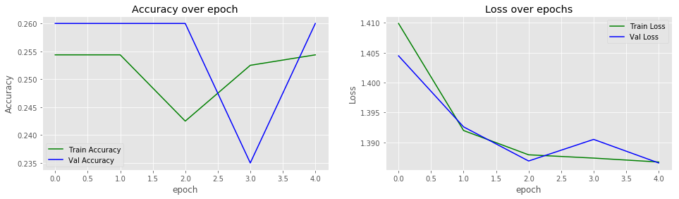

```python
network1.plot_progress()
```

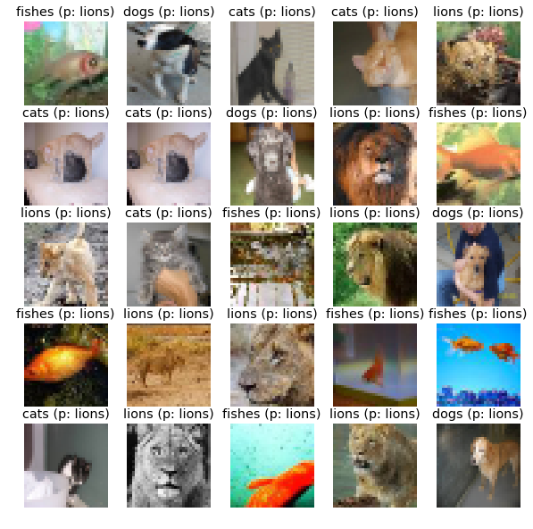

```python
network1.plot_prediction(data_manager.X_test, data_manager.y_test, data_manager.classes)
```

**Question 3.2** **Normally the first parameter to tune in Deep Learning is learning rate. In this question, you'll try running the default model with different learning rates (recommended between 0.00001 and 0.1) by entering the value in the cell below and run it. Report the learning rates you tried along with the validation accuracy for each learning rate. What is the final learning rate that you'll use? Why?.**

[5 points]

**[Write your answer here] **

Answer

Although the graph of "learning rate = 0.00001" seems to be a better option, it needs more number of epochs to converge, which take longer time. Therefore, it is not considered in this case.

- 0.1

  > Epoch 049: train loss=1.4007, val loss=1.3827  
  > : train acc=0.2369, val acc=0.3050 Finish training and come to testing  
  > INFO:tensorflow:Restoring parameters from models/network2/saved/model.ckpt  
  > Testing accuracy= 0.3000

[figure not shown]

- 0.01

  > Epoch 049: train loss=0.0156, val loss=2.9848  
  > : train acc=0.9950, val acc=0.7100 Finish training and come to testing  
  > INFO:tensorflow:Restoring parameters from models/network2/saved/model.ckpt  
  > Testing accuracy= 0.5900

[figure not shown]

- 0.001

  > Epoch 049: train loss=0.0006, val loss=2.1024  
  > : train acc=1.0000, val acc=0.7000 Finish training and come to testing  
  > INFO:tensorflow:Restoring parameters from models/network2/saved/model.ckpt  
  > Testing accuracy= 0.6700

[figure not shown]

- 0.0001

[figure not shown]

- 0.00001

[figure not shown]

```python
# YOU ARE REQUIRED TO INSERT YOUR CODES IN THIS CELL

network2 = DefaultModel(name='network2',
                        num_classes=len(data_manager.classes),
                        optimizer='adam',
                        learning_rate= 0.0001# enter your final learning rate here
                       )
```

```python
network2.fit(data_manager, batch_size=64, num_epochs=50)
```

```
Epoch 000: train loss=1.4050, val loss=1.4311

         : train acc=0.2713, val acc=0.2650

Epoch 001: train loss=1.3775, val loss=1.3887

         : train acc=0.3212, val acc=0.3100

Epoch 002: train loss=1.3591, val loss=1.3659

         : train acc=0.3369, val acc=0.3350

Epoch 003: train loss=1.3411, val loss=1.3499

         : train acc=0.3594, val acc=0.3700

Epoch 004: train loss=1.3238, val loss=1.3248

         : train acc=0.3787, val acc=0.3950

Epoch 005: train loss=1.3084, val loss=1.3156

         : train acc=0.4044, val acc=0.4050

Epoch 006: train loss=1.2908, val loss=1.2864

         : train acc=0.4144, val acc=0.3950

Epoch 007: train loss=1.2746, val loss=1.2686

         : train acc=0.4319, val acc=0.4150

Epoch 008: train loss=1.2588, val loss=1.2453

         : train acc=0.4363, val acc=0.4500

Epoch 009: train loss=1.2425, val loss=1.2293

         : train acc=0.4606, val acc=0.4950

```

[output cut: 148 more lines]

```
Epoch 047: train loss=0.8990, val loss=0.8487

         : train acc=0.6306, val acc=0.6500

Epoch 048: train loss=0.8928, val loss=0.8422

         : train acc=0.6356, val acc=0.6300

Epoch 049: train loss=0.8890, val loss=0.8397

         : train acc=0.6363, val acc=0.6350

Finish training and come to testing
INFO:tensorflow:Restoring parameters from models/network2/saved/model.ckpt
Testing accuracy= 0.6000
```

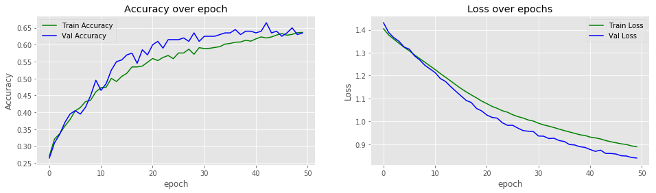

```python
network2.plot_progress()
```

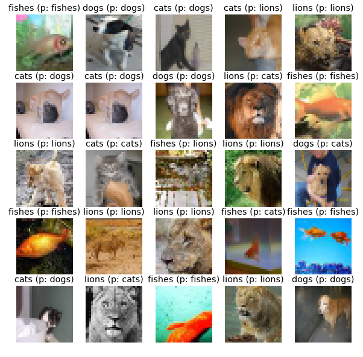

```python
# Plot images and prediction
network2.plot_prediction(data_manager.X_test, data_manager.y_test, data_manager.classes)
```

**For question 3.3 to 3.6, you'll need to write your own model in a way that makes it easy for you to experiment with different architectures as well as parameters. The goal is to be able to pass the parameters to initialize a new instance of `YourModel` to build different network architectures with different parameters. Below is descriptions of some parameters for `YourModel`, which you can find in function `__init__()` for the class `DefaultModel`:**

1. `num_blocks`: an integer specifying the number of blocks in our network. Each block has the pattern `[conv, batch norm, activation, conv, batch norm, mean pool, dropout]`. All convolutional layers have filter size $(3, 3)$, strides $(1, 1)$ and 'SAME' padding, and all mean pool layers have strides $(1, 2)$ and 'SAME' padding. The network will consists of a few blocks before applying a linear layer to output the logits for the softmax layer.
2. `feature_maps`: the number of feature maps in the first block of the network. The number of feature_maps will double in each of the following block. To make it convenient for you, we already calculated the number of feature maps for each block for you in line $162$
3. `keep_prob`: the keep probability for dropout. Setting `keep_prob` to $1.0$ means not using dropout. Notice that dropout is not used in the inference phase. Therefore, you should pass the placeholder `self.keep_prob_holder` (line $203$) to the dropout layers. The place holder will take the value of `keep_prob` during training phase (line $270$) and the value of $1.0$ during inference phase (line $326$ and $332$).
4. `batch_norm`: the batch normalization function to be use, such as tf.layers.batch_normalization. Setting `batch_norm` to `None` means not using batch normalization. Notice that the batch normalization should take a parameter `training`, which specifies whether the computation is in the training (True) or inference (False) phase, and which is passed to the computational graph through `self.phase_train` (see line $204$, $270$, $327$)

**You'll only need to re-write the code for the `build_cnn` function for the `YourModel` class from the cell below.**

```python
# YOU ARE REQUIRED TO INSERT YOUR CODES IN THIS CELL

import tensorflow as tf

class YourModel(DefaultModel):
    def build_cnn(self, x, reuse=False, name='CNN'):
        # ENTER YOUR CODES HERE
        with tf.variable_scope(name, reuse=reuse):

            # for each block
            for i in range(self.num_blocks):

                h = Layers.conv2D(x, self.feature_maps[i], kernel_size=3, strides=1, name='block'+str(i)+'.conv0')
                tf.summary.histogram('block'+str(i)+'.conv0', h)
                if self.batch_norm is not None:
                    h = self.batch_norm(h, self.phase_train, name='block'+str(i)+'.bn0')
                    tf.summary.histogram('block'+str(i)+'.bn0', h)
                h = self.activation_func(h, name='block'+str(i)+'.relu0')
                tf.summary.histogram('block'+str(i)+'.relu0', h)

                h = Layers.conv2D(h, self.feature_maps[i], kernel_size=3, strides=1, name='block'+str(i)+'.conv1')
                tf.summary.histogram('block'+str(i)+'.conv1', h)
                if self.batch_norm is not None:
                    h = self.batch_norm(h, self.phase_train, name='block'+str(i)+'.bn1')
                    tf.summary.histogram('block'+str(i)+'.bn1', h)
                h = self.activation_func(h, name='block'+str(i)+'relu1')
                tf.summary.histogram('block'+str(i)+'.relu1', h)
                h = Layers.mean_pool(h, name='block'+str(i)+'.avg_pool')
                h = Layers.dropout(h, self.keep_prob_holder, name='block'+str(i)+'.dropout')

                x=h

            # after all block
            # reshape and use a fully connected layer
            h = tf.reshape(h, [-1, h.get_shape()[1] * h.get_shape()[2] * h.get_shape()[3]])

            # now output the logits for softmax classification
            logits = Layers.dense(h, self.num_classes, name='output.logits')
            tf.summary.histogram('output.logits', logits)
            return logits
```

**Question 3.3** Once writing your own models, you should be able to use it to experiment with dropout or batch normalization. In this question, you'll use your model to finetune the dropout rate. Report the `keep_prob` rates you tried along with the validation accuracy for each rate (recomended range: 0.5 to 0.8). What is the final `keep_prob` rate that you'll use? Did dropout improve performance? Did it help reduce overfitting?.

[7.5 points]

**[Write your answer here] **

Answer

(Note: the comparison here is made using "learning rate = 0.001")

- 0.8

[figure not shown]

- 0.7

  > Epoch 049: train loss=0.0159, val loss=1.4970  
  > : train acc=0.9994, val acc=0.7250 Finish training and come to testing  
  > INFO:tensorflow:Restoring parameters from models/network3/saved/model.ckpt  
  > Testing accuracy= 0.7000

[figure not shown]

- 0.6

  > Epoch 049: train loss=0.0331, val loss=1.5379  
  > : train acc=0.9919, val acc=0.7050 Finish training and come to testing  
  > INFO:tensorflow:Restoring parameters from models/network3/saved/model.ckpt  
  > Testing accuracy= 0.7100

[figure not shown]

- 0.5

[figure not shown]

```python
# YOU ARE REQUIRED TO INSERT YOUR CODES IN THIS CELL

network3 = YourModel(name='network3',
                     feature_maps=32,
                     num_classes=len(data_manager.classes),
                     keep_prob= 0.5# enter your final keep_prob value here
                     ,
                     batch_norm=None,
                     optimizer='adam',
                     learning_rate=0.001)
network3.fit(data_manager, batch_size=64, num_epochs=50)
```

```
Epoch 000: train loss=0.9733, val loss=1.0178

         : train acc=0.5494, val acc=0.5050

Epoch 001: train loss=0.8304, val loss=0.9827

         : train acc=0.6737, val acc=0.6450

Epoch 002: train loss=0.7603, val loss=1.0079

         : train acc=0.6787, val acc=0.6400

Epoch 003: train loss=0.7292, val loss=1.0065

         : train acc=0.7056, val acc=0.6200

Epoch 004: train loss=0.6474, val loss=0.9234

         : train acc=0.7281, val acc=0.6150

Epoch 005: train loss=0.5771, val loss=0.8875

         : train acc=0.7825, val acc=0.6100

Epoch 006: train loss=0.5461, val loss=0.9163

         : train acc=0.7931, val acc=0.6300

Epoch 007: train loss=0.4736, val loss=0.8980

         : train acc=0.8250, val acc=0.6650

Epoch 008: train loss=0.4662, val loss=0.8916

         : train acc=0.8263, val acc=0.6450

Epoch 009: train loss=0.4710, val loss=1.0006

         : train acc=0.8125, val acc=0.6550

```

[output cut: 148 more lines]

```
Epoch 047: train loss=0.0331, val loss=1.8444

         : train acc=0.9919, val acc=0.7000

Epoch 048: train loss=0.0086, val loss=1.8619

         : train acc=1.0000, val acc=0.6800

Epoch 049: train loss=0.0201, val loss=2.0455

         : train acc=0.9969, val acc=0.6650

Finish training and come to testing
INFO:tensorflow:Restoring parameters from models/network3/saved/model.ckpt
Testing accuracy= 0.7050
```

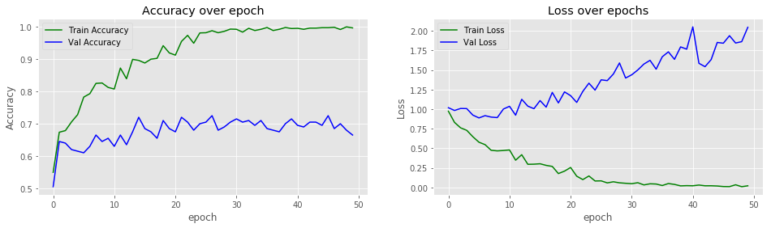

```python
network3.plot_progress()
```

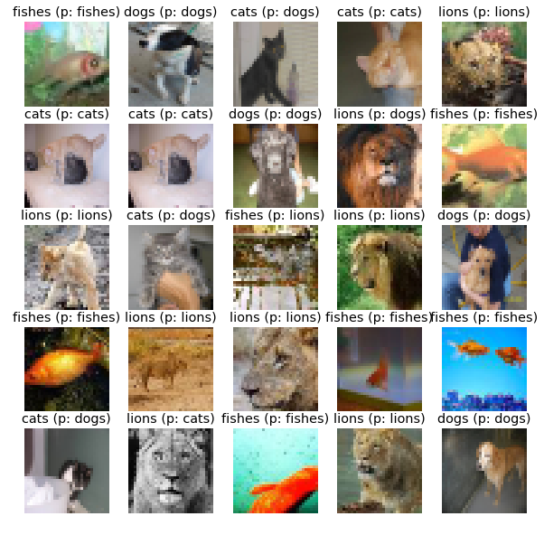

```python
network3.plot_prediction(data_manager.X_test, data_manager.y_test, data_manager.classes)
```

**Question 3.4** Now, let's try using batch normalization. Define a batch norm function to be used by your model in the following cell and run the cell to train the model. What is the validation and test result? Does it improve the model? How does it compare to the model using dropout?

[7.5 points]

**[Write your answer here] **

Answer

The validation result is 0.7700 and the test result is 0.7400. The batch normalization (BN) did improve the model as BN increases the validation and test accuracy and decreases the gap between train accuracy and validation/test accuracy (also the gap between both train loss and validation loss). Compared to the one with the dropout used, the improvement made by the BN one is more significant than the dropout one but both of them did reduce overfitting.

(Note: the comparison here is made using "learning rate = 0.001")

> Epoch 049: train loss=0.0012, val loss=1.0698  
> : train acc=1.0000, val acc=0.7700 Finish training and come to testing  
> INFO:tensorflow:Restoring parameters from models/network4/saved/model.ckpt  
> Testing accuracy= 0.7400

```python
# YOU ARE REQUIRED TO INSERT YOUR CODES IN THIS CELL

batch_norm = lambda inputs, phase_train, name:tf.layers.batch_normalization(inputs, momentum=0.9, epsilon=1e-5, training=phase_train, name=name)# define the function here
```

```python
network4 = YourModel(name='network4',
                     feature_maps=32,
                     num_classes=len(data_manager.classes),
                     keep_prob=1.0, # don't use dropout in this experiment
                     batch_norm=batch_norm,
                     optimizer='adam',
                     learning_rate=0.001)
network4.fit(data_manager, batch_size=64, num_epochs=50)
```

```
Epoch 000: train loss=0.8481, val loss=1.2029

         : train acc=0.6500, val acc=0.6000

Epoch 001: train loss=0.6077, val loss=1.0012

         : train acc=0.7800, val acc=0.6550

Epoch 002: train loss=0.4669, val loss=0.9367

         : train acc=0.8219, val acc=0.6650

Epoch 003: train loss=0.4040, val loss=0.8345

         : train acc=0.8562, val acc=0.7000

Epoch 004: train loss=0.2914, val loss=0.8370

         : train acc=0.9112, val acc=0.7250

Epoch 005: train loss=0.3125, val loss=0.9868

         : train acc=0.8938, val acc=0.7000

Epoch 006: train loss=0.2635, val loss=0.8696

         : train acc=0.9075, val acc=0.7000

Epoch 007: train loss=0.2220, val loss=0.8587

         : train acc=0.9300, val acc=0.7200

Epoch 008: train loss=0.1583, val loss=0.8455

         : train acc=0.9606, val acc=0.7200

Epoch 009: train loss=0.1357, val loss=0.8053

         : train acc=0.9669, val acc=0.7050

```

[output cut: 148 more lines]

```
Epoch 047: train loss=0.0013, val loss=1.0524

         : train acc=1.0000, val acc=0.7750

Epoch 048: train loss=0.0013, val loss=1.0703

         : train acc=1.0000, val acc=0.7700

Epoch 049: train loss=0.0012, val loss=1.0698

         : train acc=1.0000, val acc=0.7700

Finish training and come to testing
INFO:tensorflow:Restoring parameters from models/network4/saved/model.ckpt
Testing accuracy= 0.7400
```

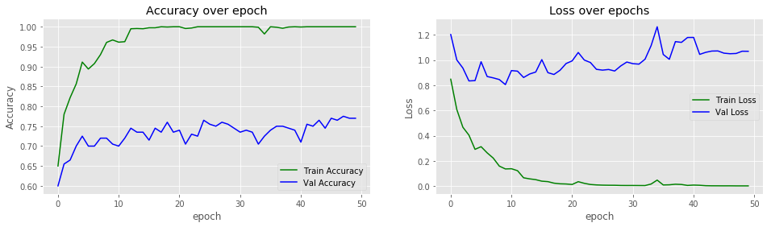

```python
network4.plot_progress()
```

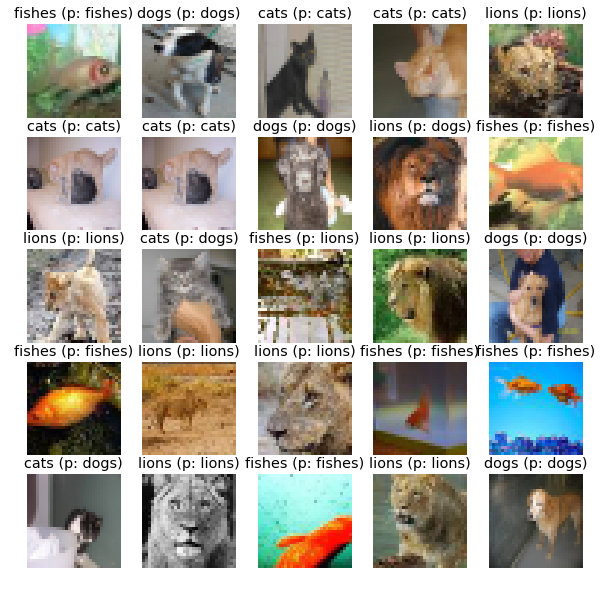

```python
network4.plot_prediction(data_manager.X_test, data_manager.y_test, data_manager.classes)
```

**Question 3.5** Finally, you should try to train the best model by trying different configurations for `num_blocks`, `feature_maps`, `optimizer`, `learning_rate`, `batch_size`, `keep_prob` and `batch_norm`. Briefly report the experiments that you try and your observation in the answer below. Also, run the cells below with the best configuration you found.

[5 points]

**[Write your answer here] **

Answer

#### Abbreviation used:

- DP = Dropout
- BN = Batch Normalization
- BS = Batch Size
- NB = Number of Blocks
- FM = Feautre Maps

#### First Attempt

First, I try with the optimal keep_prob rate mentioned above and the batch normalization as the starting point.

- DP0.5 + BN

  > Epoch 049: train loss=0.2337, val loss=1.2032  
  > : train acc=0.9112, val acc=0.7050 Finish training and come to testing  
  > INFO:tensorflow:Restoring parameters from models/network5/saved/model.ckpt  
  > Testing accuracy= 0.7400

[figure not shown]

#### Second Attempt

I found that the trend in the figure shown above has some noises within it, so it probably does something with the keep_prob rate. For this time, I increase the rate by 0.1.

- DP0.6 + BN

  > Epoch 049: train loss=0.0681, val loss=1.1538  
  > : train acc=0.9756, val acc=0.7400 Finish training and come to testing  
  > INFO:tensorflow:Restoring parameters from models/network5/saved/model.ckpt  
  > Testing accuracy= 0.7500

[figure not shown]

#### Third Attempt

Both the validation and testing accuracies are improved. Let's try with 0.8 this time.

- DP0.8 + BN

[figure not shown]

#### Fourth Attempt

With the previous attempt, there is a little improvement obtained and the graph seems like there are other factors to be dealt with. Let's try with "batch_size = 80" this time.

- DP0.8 + BN + BS80

  > Epoch 049: train loss=0.0136, val loss=1.1823  
  > : train acc=0.9994, val acc=0.7150 Finish training and come to testing  
  > INFO:tensorflow:Restoring parameters from models/network5/saved/model.ckpt  
  > Testing accuracy= 0.7750

[figure not shown]

#### Fifth Attempt

Changing the batch size does not really improve as the gap between validation and testing accuracies increases (they should have similar value (difference of 2-4). The number of blocks are tested this time with "num_blocks = 1".

- DP0.8 + BN + NB1

  > Epoch 049: train loss=0.0073, val loss=1.5914  
  > : train acc=1.0000, val acc=0.7000 Finish training and come to testing  
  > INFO:tensorflow:Restoring parameters from models/network5/saved/model.ckpt  
  > Testing accuracy= 0.6800

[figure not shown]

#### Sixth Attempt

Obviously, the fifth attempt does not work as desired. The configuration changed this time is the size of feature maps in the first block, which is "feature_maps=16".

- DP0.8 + BN + FM16

[figure not shown]

#### Final Decision

- The best optimizer in the current trend is said to be Adam.
- Decreasing learning rate takes more num_epochs, which means that it consumes more time.
- Since learning rate is unchanged, increasing num_epochs would not help as the result is showing overfitting problem.

```python
# YOU ARE REQUIRED TO INSERT YOUR CODES IN THIS CELL

# ENTER YOUR BEST MODEL CONFIGURATION HERE

batch_norm = lambda inputs, phase_train, name:tf.layers.batch_normalization(inputs, momentum=0.9, epsilon=1e-5, training=phase_train, name=name)# define the function here# define the function here if needed
network5 = YourModel(name='network5',
                     num_blocks=2,
                     feature_maps=32,
                     num_classes=len(data_manager.classes),
                     keep_prob= 0.8,
                     batch_norm=batch_norm,
                     optimizer='adam',
                     learning_rate=0.001# enter your best configuration here
                    )

network5.fit(data_manager,
             batch_size= 64# enter your optimal batch_size here
             , num_epochs= 50# enter your optimal num_epochs here
             )
```

```
Epoch 000: train loss=0.9781, val loss=1.0620

         : train acc=0.5769, val acc=0.5100

Epoch 001: train loss=0.8306, val loss=1.0410

         : train acc=0.6594, val acc=0.6000

Epoch 002: train loss=0.7412, val loss=1.1145

         : train acc=0.7100, val acc=0.6400

Epoch 003: train loss=0.7630, val loss=1.1873

         : train acc=0.6625, val acc=0.5750

Epoch 004: train loss=0.6111, val loss=0.9845

         : train acc=0.7700, val acc=0.6500

Epoch 005: train loss=0.5737, val loss=1.0248

         : train acc=0.7788, val acc=0.6250

Epoch 006: train loss=0.5370, val loss=1.0280

         : train acc=0.7825, val acc=0.6800

Epoch 007: train loss=0.5448, val loss=1.0585

         : train acc=0.7894, val acc=0.6450

Epoch 008: train loss=0.4945, val loss=1.0899

         : train acc=0.8031, val acc=0.6200

Epoch 009: train loss=0.4571, val loss=1.0200

         : train acc=0.8200, val acc=0.6600

```

[output cut: 148 more lines]

```
Epoch 047: train loss=0.0514, val loss=1.0413

         : train acc=0.9912, val acc=0.7200

Epoch 048: train loss=0.0816, val loss=1.0720

         : train acc=0.9831, val acc=0.7150

Epoch 049: train loss=0.0530, val loss=0.9864

         : train acc=0.9931, val acc=0.7400

Finish training and come to testing
INFO:tensorflow:Restoring parameters from models/network5/saved/model.ckpt
Testing accuracy= 0.7550
```

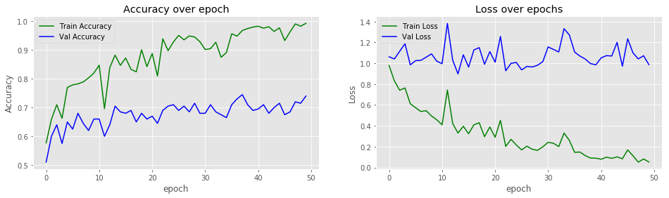

```python
network5.plot_progress()
```

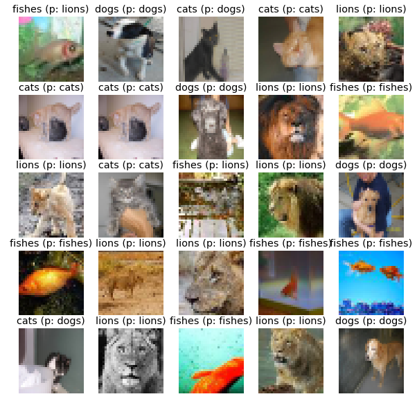

```python
network5.plot_prediction(data_manager.X_test, data_manager.y_test, data_manager.classes)
```

**END OF ASSIGNMENT**